# AI Adoption and U.S. Unemployment Trends

```r
# Load libraries
library(pacman)
p_load(tidyverse, stringr, purrr, pander, zoo)
```

## Project Overview

I have been a Software Engineering student at Brigham Young University–Idaho since 2022, and throughout that time I have seen growing concern, both among students and across social media, about the weakening job market in technology and computer science related fields. Many describe the market as “cooked,” meaning that internship and entry-level opportunities have become increasingly difficult to secure. This project was motivated by a desire to understand whether there is evidence of a relationship between the rise of artificial intelligence adoption within firms and the employment outcomes of recent graduates.

Recent reporting reinforces these concerns. According to The Wall Street Journal and related analyses from early 2025, Harvard Business School experienced a substantial increase in unemployed MBA graduates: approximately 23% of the Class of 2024 were still seeking jobs three months after graduation. This marks a significant rise from 10% in 2022 and 20% in 2023. The reports attribute this trend to a cooling white-collar labor market, reduced hiring by large technology and consulting firms such as Amazon, Google, and McKinsey, and shifting corporate priorities. These dynamics have affected even the highest-ranked programs, with some graduates turning toward contract or temporary work.

### Research Question

This project examines whether the rapid rise in artificial intelligence usage, proxied by monthly ChatGPT user estimates and Google Trends interest, has been associated with changes in U.S. employment conditions. Specifically, the study focuses on the following primary research question:

**To what extent is the growth in AI adoption, measured through ChatGPT usage metrics and national search interest, associated with changes in the U.S. unemployment rate from 2023 to 2025?**

### Data Sources

This analysis integrates multiple U.S. focused datasets to evaluate the relationship between AI adoption and employment conditions. The datasets include labor market indicators, AI usage metrics, and search-based measures of public interest. All sources are publicly available and are listed below:

1. AI Tool Adoption Dataset (Kaggle)  
   Provides AI adoption rates at industry level, daily active user estimates, and demographic segments such as age group and company size.  
   Source: https://www.kaggle.com/datasets/tfisthis/global-ai-tool-adoption-across-industries/data
2. U.S. Unemployment Rate for Recent College Graduates (BLS / FRED Series CGBD2534)  
   Contains monthly unemployment rates for individuals aged 25–34 with a bachelor’s degree or higher. Used as the primary employment indicator in this study.  
   Source: https://fred.stlouisfed.org/series/CGBD2534
3. Google Trends Data for “ChatGPT” Interest (2020–2025)  
   Measures national search intensity for the term “ChatGPT,” used as a proxy for public and industry engagement with large language model tools. Google Trends is included because search interest tends to correlate with periods of high adoption, product rollouts, or increased workplace integration, making it a suitable indicator of broader AI engagement over time.
4. Monthly ChatGPT User Estimates (First Page Sage)  
   Provides approximate monthly active user counts (in millions) for ChatGPT from 2024–2025. This dataset supplements the Google Trends data by offering a direct measure of AI usage.  
   Source: [https://firstpagesage.com/seo-blog/chatgpt-usage-statistics/](https://firstpagesage.com/seo-blog/chatgpt-usage-statistics/?utm_source=chatgpt.com)

## Data Cleaning and Preparation

This project integrates three separate time-series datasets, each with its own structure and level of granularity. Prior to analysis, all datasets were cleaned, standardized, and aligned to a common monthly format.

**1. BLS/FRED Unemployment Data (unemp_df)**  
The unemployment dataset contains monthly observations for U.S. workers aged 25–34 with at least a bachelor’s degree. Cleaning steps included:

- Parsing the `observation_date` column into a proper date format.
- Creating a `month_date` variable using `floor_date()` to standardize the timestamp.
- Renaming fields for clarity (e.g., `CGBD2534` → `unemployment_rate`).
- Removing any incomplete observations.

**3. ChatGPT Monthly User Estimates (chatgpt_users)**  
This dataset, sourced from publicly available usage estimates, was manually entered as a tibble. Preparation steps included:

- Parsing each month string into a `month_date` variable.
- Creating an indexed usage metric (`users_index`) to track growth relative to the first available month.
- Verifying that data types remained numeric and consistent across joins.

Across all datasets, missing values were minimal. Any NAs present were removed during preprocessing to maintain consistent joins and avoid distortions in summary statistics.

```r
# Load datasets
ai_adoption <- read_csv('sem_proj_data/ai_adoption_dataset.csv', show_col_types = FALSE)
unemp_df  <- read_csv('sem_proj_data/CGUNRATE.csv', show_col_types = FALSE)
chat_interest <- read_csv('sem_proj_data/chat_gpt_interest.csv', show_col_types = FALSE)

# Clean chat_interest
chat_interest_clean <- chat_interest %>%
  slice(-1) %>%
  # split "2020-12-06,0" into date_str and value_str
  separate(
    `Category: All categories`,
    into = c("date_str", "interest"),
    sep = ",",
    remove = TRUE
  ) %>%
  mutate(
    date       = ymd(date_str),
    interest   = as.numeric(interest),
    year       = year(date),
    month      = month(date),
    month_date = floor_date(date, unit = "month")
  )

# Source: https://firstpagesage.com/seo-blog/chatgpt-usage-statistics/
chatgpt_users <- tribble(
  ~month,        ~users_millions,
  "2024-09-01", 437,
  "2024-10-01", 444,
  "2024-11-01", 461,
  "2024-12-01", 476,
  "2025-01-01", 481,
  "2025-02-01", 483,
  "2025-03-01", 501,
  "2025-04-01", 541,
  "2025-05-01", 603,
  "2025-06-01", 723,
  "2025-07-01", 812,
  "2025-08-01", 838,
  "2025-09-01", 845,
  "2025-10-01", 856
) %>%
  mutate(
    month_date  = ymd(month),
    users_index = users_millions / first(users_millions) * 100
  )

unemp_df <- unemp_df %>%
  rename(unemployment_rate = 'CGBD2534')

unemp_monthly <- unemp_df %>%
  mutate(
    observation_date = ymd(observation_date),
    month_date       = floor_date(observation_date, unit = "month")
  ) %>%
      select(month_date, unemployment_rate)

filtered_adoption <- ai_adoption %>%
  filter(country == 'USA')

filtered_adoption_monthly <- filtered_adoption %>%
  group_by(year) %>%
  summarise(mean_adoption = mean(adoption_rate, na.rm = TRUE)) %>%
  mutate(month_date = ymd(paste0(year, "-01-01"))) %>%
  select(month_date, mean_adoption)

# Combine datasets
combined_adoption_plot <- unemp_monthly %>%
  inner_join(filtered_adoption_monthly, by = "month_date") %>%
  arrange(month_date)
```

## Exploratory Data Analysis

The exploratory analysis assesses the structure and suitability of the three datasets used in the study and ensures that they align by date, frequency, and measurement scale.

**1. Unemployment Data (BLS/FRED)**

The `unemp_monthly` dataset contains the monthly unemployment rate for U.S. individuals with a bachelor’s degree or higher. After converting dates into a standardized monthly format, the series is clean, continuous, and has no missing values. The key variable of interest is `unemployment_rate`, and the creation of `month_date` enables efficient joining with the AI datasets.

**2. Google Trends Interest in “ChatGPT”**

Google Trends provides weekly U.S. search interest for the term “ChatGPT,” normalized on a 0–100 scale. While it does not measure actual enterprise usage, search activity is a widely used proxy for the diffusion of new technologies and often reflects increases in public and organizational engagement.

**3. Kaggle AI Adoption Dataset**

The Kaggle dataset captures AI adoption rates in the U.S. by industry, company size, and age group, along with daily active user estimates. Initial grouped summaries show:

- Adoption rates are similar across company sizes (enterprise, SME, startup).
- Age groups exhibit comparable levels of daily active usage.

```r
company_summary <- filtered_adoption %>%
  group_by(company_size) %>%
  summarise(
    n_obs           = n(),
    mean_adoption   = mean(adoption_rate, na.rm = TRUE),
    median_adoption = median(adoption_rate, na.rm = TRUE),
    mean_dau        = mean(daily_active_users, na.rm = TRUE)
  ) %>%
  select(company_size, n_obs, median_adoption) %>%
  arrange(desc(median_adoption))

pander(company_summary)
```

| company_size | n_obs | median_adoption |
| --- | --- | --- |
| Startup | 4906 | 49.53 |
| Enterprise | 4664 | 49.35 |
| SME | 4782 | 48.5 |

```r
age_summary <- filtered_adoption %>%
  group_by(age_group) %>%
  summarise(
    n_obs           = n(),
    mean_adoption   = mean(adoption_rate, na.rm = TRUE),
    median_adoption = median(adoption_rate, na.rm = TRUE),
    mean_dau        = mean(daily_active_users, na.rm = TRUE)
  ) %>%
    select(age_group, n_obs, median_adoption) %>%
  arrange(desc(median_adoption))

pander(age_summary)
```

| age_group | n_obs | median_adoption |
| --- | --- | --- |
| 35-44 | 2936 | 49.97 |
| 18-24 | 2745 | 49.35 |
| 45-54 | 2811 | 48.96 |
| 55+ | 3012 | 48.7 |
| 25-34 | 2848 | 48.64 |

```r
combo_summary <- filtered_adoption %>%
  group_by(company_size, age_group) %>%
  summarise(
    n_obs         = n(),
    mean_adoption = mean(adoption_rate, na.rm = TRUE),
    mean_dau      = mean(daily_active_users, na.rm = TRUE),
    .groups = "drop"
  ) %>%
  arrange(company_size, desc(mean_adoption))

combined_interest <- unemp_monthly %>%
  inner_join(chat_interest_clean, by = "month_date")

combined_users <- unemp_monthly %>%
  inner_join(chatgpt_users, by = "month_date")
```

These patterns help demonstrate broader AI adoption trends and support later interpretation of relationships between AI activity and unemployment outcomes.

### Data Visualization

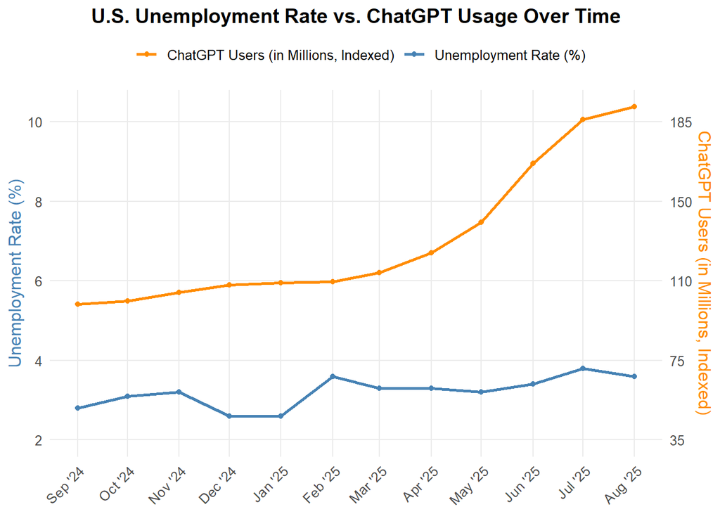

```r
scale_factor <- max(unemp_monthly$unemployment_rate, na.rm = TRUE) /
                max(chatgpt_users$users_index, na.rm = TRUE)
combined_plot_df <- unemp_monthly %>%
  inner_join(chatgpt_users, by = "month_date")

right_axis_values <- seq(2, 10, by = 2) / scale_factor
right_axis_labels <- round(right_axis_values / 5) * 5

ggplot(combined_plot_df, aes(x = month_date)) +
  geom_line(aes(y = unemployment_rate, color = "Unemployment Rate (%)"), linewidth = 1) +
  geom_point(aes(y = unemployment_rate, color = "Unemployment Rate (%)"), size = 1.5) +
  geom_line(aes(y = users_index * scale_factor, color = "ChatGPT Users (in Millions, Indexed)"), linewidth = 1) +
  geom_point(aes(y = users_index * scale_factor, color = "ChatGPT Users (in Millions, Indexed)"), size = 1.5) +
  scale_y_continuous(
    name = "Unemployment Rate (%)",
    breaks = seq(2, 10, by = 2),
    limits = c(2, NA),
    sec.axis = sec_axis(
      ~ . / scale_factor,
      name = "ChatGPT Users (in Millions, Indexed)",
      breaks = seq(2, 10, by = 2) / scale_factor,
      labels = right_axis_labels
    )
  ) +
  scale_x_date(
    date_breaks = "1 month",
    date_labels = "%b '%y"
  ) +
  scale_color_manual(values = c("darkorange", "steelblue")) +
  labs(
    title = "U.S. Unemployment Rate vs. ChatGPT Usage Over Time",
    color = "",
    x = NULL
  ) +
  theme_minimal() +
  theme(
    text = element_text(size = 12),
    plot.title = element_text(face = "bold", size = 14, hjust = 0.5),
    axis.text.x = element_text(angle = 45, hjust = 1),
    axis.title.y.right = element_text(color = "darkorange"),
    axis.title.y.left = element_text(color = "steelblue"),
    panel.grid.minor = element_blank(),
    legend.position = "top"
  )
```

This dual-axis time series chart examines the relationship between monthly U.S. unemployment rates and ChatGPT user growth (indexed), serving as a proxy for AI adoption in the labor market. The visualization employs a scaled secondary y-axis to compare unemployment percentage (left) with indexed user counts (right) on a unified timeline from September 2024 through August 2025.

**Technical Approach:**

- Applied a scaling factor to normalize both metrics for visual comparison while maintaining their distinct units
- Used dual y-axes with rounded intervals to enhance readability
- Implemented color coded lines and markers to distinguish between unemployment trends (blue) and AI adoption (orange)

**Key Findings:**

The analysis reveals substantial ChatGPT user growth, nearly doubling from an index of ~100 to ~185—during a period when unemployment remained relatively stable, fluctuating between 2.5% and 4.0%. Notably, the accelerated AI adoption phase (May-August 2025) shows no corresponding spike in unemployment, suggesting that short-term labor market dynamics are driven more by cyclical economic factors than by AI technology diffusion.

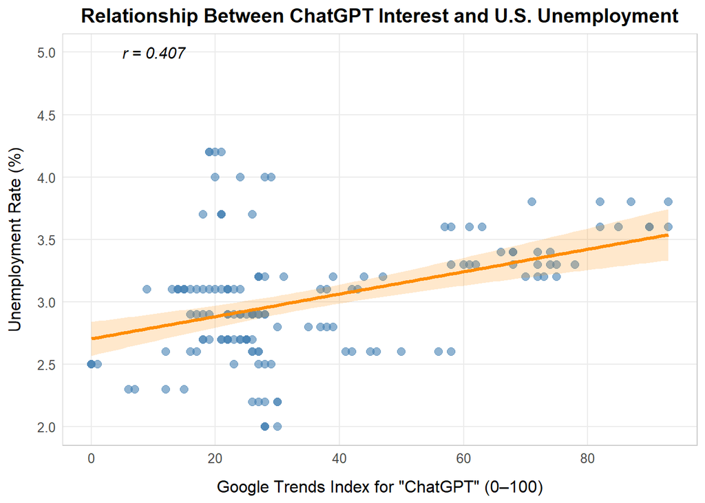

```r
combined_interest_filtered <- combined_interest %>%
  filter(month_date >= "2022-11-01")

# Calculate correlation
cor_value <- cor(combined_interest_filtered$interest, combined_interest_filtered$unemployment_rate,
                 use = "complete.obs")

ggplot(combined_interest_filtered, aes(x = interest, y = unemployment_rate)) +
  geom_point(alpha = 0.6, color = "steelblue", size = 2.5) +
  geom_smooth(method = "lm", se = TRUE, color = "darkorange",
              fill = "darkorange", alpha = 0.2, linewidth = 1.2) +
  annotate("text", x = 5, y = 5,
           label = paste0("r = ", round(cor_value, 3)),
           hjust = 0, size = 4, fontface = "italic") +
  labs(
    title = "Relationship Between ChatGPT Interest and U.S. Unemployment",
    x = "Google Trends Index for \"ChatGPT\" (0–100)",
    y = "Unemployment Rate (%)"
  ) +
  theme_minimal() +
  theme(
    text = element_text(size = 12),
    plot.title = element_text(face = "bold", size = 14, hjust = 0.5),
    axis.title.x = element_text(margin = margin(t = 10)),
    axis.title.y = element_text(margin = margin(r = 10)),
    panel.grid.minor = element_blank(),
    panel.border = element_rect(color = "gray80", fill = NA, linewidth = 0.5)
  ) +
  scale_x_continuous(breaks = seq(0, 100, by = 20)) +
  scale_y_continuous(breaks = seq(2, 5, by = 0.5))
```

**Key Technical Approach:**

- Filtered data to include only the ChatGPT era (November 2022-present) to ensure meaningful comparison
- Compiled monthly data pairing Google Trends search interest for “ChatGPT” with corresponding U.S. unemployment rates
- Applied ordinary least squares (OLS) regression to quantify the relationship between AI interest and unemployment
- Optimized visualization with enhanced point visibility, explicit axis breaks, and minimal gridlines for clarity

**Key Findings:**

The analysis reveals a **moderate positive correlation (r = 0.407)** between ChatGPT search interest and unemployment rates. While the relationship is measurable and significant, the substantial scatter around the regression line indicates that other factors beyond AI interest play important roles in unemployment dynamics.

## Statistical Analysis

To quantify the relationship between ChatGPT interest and unemployment rates, I performed ordinary least squares (OLS) linear regression on data from November 2022 onward, when ChatGPT became publicly available.

Below, we can see the regression model indicates a statistically significant relationship **(p < 0.001, adjusted R² = 0.16),** suggesting that ChatGPT interest explains approximately 16% of unemployment variation during this period. **For every 10 point increase in ChatGPT search interest, unemployment rates increase by roughly 0.09** percentage points.

```r
mylm <- lm(unemployment_rate ~ interest, data = combined_interest_filtered)
mysumm <- summary(mylm)
pander(mysumm)
```

|  | Estimate | Std. Error | t value | Pr(>\|t\|) |
| --- | --- | --- | --- | --- |
| **(Intercept)** | 2.705 | 0.06864 | 39.4 | 1.089e-79 |
| **interest** | 0.008971 | 0.001665 | 5.387 | 2.811e-07 |

Fitting linear model: unemployment_rate ~ interest

| Observations | Residual Std. Error | $R^2$ | Adjusted $R^2$ |
| --- | --- | --- | --- |
| 148 | 0.4504 | 0.1658 | 0.1601 |

### Checking Assumptions

Before drawing conclusions from the regression results, it is essential to verify that the data meet the assumptions required for valid linear regression: linearity, independence, normality of residuals, and homoscedasticity (equal variance). Violating these assumptions can invalidate p-values, confidence intervals, and coefficient estimates.

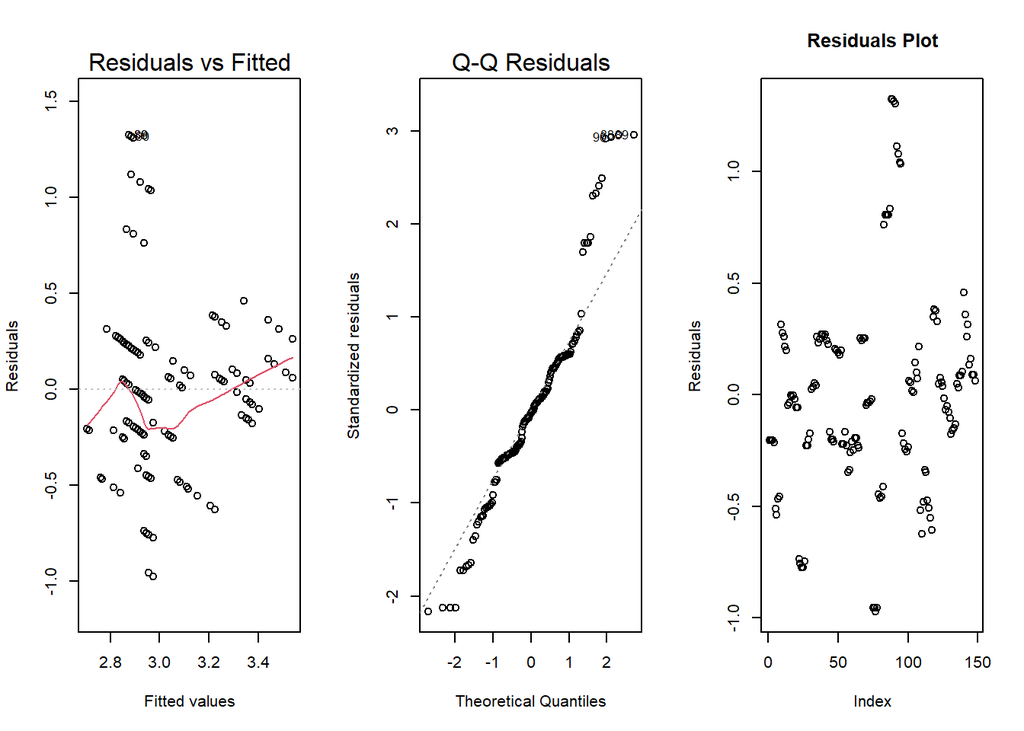

```r
# Check assumptions with diagnostic plots
par(mfrow = c(1, 3))
plot(mylm, which = 1:2)
plot(mylm$residuals, main = "Residuals Plot", ylab = "Residuals")
```

**Residuals vs. Fitted Plot (Linearity & Homoscedasticity):** The residuals show a relatively random scatter around zero with no strong curved pattern. However, there still might be some heteroscedasticity (non-constant variance) across fitted values. We can see near the fitted values 2.9 - 3.0 that the residuals are more loosely clustered, raning from around -1.0 to +1.3. Compared to the spread of near the fitted value 3.4 ranging from around -0.25 to + 0.4, we can see this is a noticeable difference.

### Implications

We can proceed with interpreting the regression results, but with appropriate caution. The findings indicate ChatGPT interest and unemployment are meaningfully related during the AI adoption period, though this relationship is imperfect and likely influenced by additional factors not included in the model. The analysis provides evidence of association rather than a complete explanatory model of unemployment dynamics.

## Discussion and Interpretation

### Key Findings

This analysis reveals a statistically significant but modest relationship between ChatGPT interest and U.S. unemployment during the AI adoption period (November 2022-August 2025). The regression analysis shows that ChatGPT search interest explains approximately 16% of unemployment variation (p < 0.001, r = 0.407), with unemployment rising by roughly 0.09 percentage points for every 10-point increase in search interest. However, this relationship must be interpreted carefully within proper context.

### What the Data Actually Shows

**Weak explanatory power**: Even with statistical significance, ChatGPT interest explains only 16% of unemployment variation, meaning traditional economic factors (monetary policy, consumer spending, business investment) remain far more influential.

**Early adoption phase**: Current patterns may reflect a period where AI primarily augments worker productivity rather than replacing workers entirely, with more substantial restructuring potentially emerging as the technology matures.

### Limitations and Future Directions

This analysis has important constraints. Google Trends measures public interest rather than actual workplace AI adoption. Unemployment rates don’t capture discouraged workers or underemployment. Future research should examine industry-specific employment trends, conduct firm-level surveys on AI implementation, and track longitudinal worker outcomes to understand how AI reshapes, rather than simply eliminate, employment opportunities.

### Implications

The absence of immediate widespread displacement provides a window for proactive policy responses: expanding retraining programs, developing portable benefits systems, focusing education on AI-complementary skills, and building monitoring systems to detect sector-specific disruptions early. The “cooked” CS job market narrative reflects real concerns, but this analysis suggests the relationship between AI and employment is more nuanced than simple displacement, involving complex dynamics of substitution, complementarity, and restructuring that will unfold over years rather than months.